# Pset 3

Author

Hood Ahmed

GitHub repository：https://github.com/hood-ahmed/Stats-506

# Problem 1

## A. Downloading & merging data

*Downloading and merging the data*

```stata
. * Read the VIX_D & DEMO_D dataset.
. * Save it as a Stata dataset.
global datadirectory C:\Users\hoodah\Downloads

clear
import sasxport5 "$datadirectory\VIX_D.XPT"
    duplicates tag seqn, gen(tag)
    assert tag==0
    drop tag
save "$datadirectory\VIX_D",replace

clear
import sasxport5 "$datadirectory\DEMO_D.XPT"
    duplicates tag seqn, gen(tag)
    assert tag==0
    drop tag

    merge 1:1 seqn using "$datadirectory\VIX_D"
    /*

    Result                      Number of obs
    -----------------------------------------
    Not matched                         3,368
        from master                     3,368  (_merge==1)
        from using                          0  (_merge==2)

    Matched                             6,980  (_merge==3)
    -----------------------------------------

    keep if _m==3
    drop _m
    di _N
    *6980
```

## B. Estimating proportion

*Estimate the proportion of respondents within each 10-year age bracket who wear glasses/contact lenses for distance vision. Produce a nice table with the results.*

Based on viq240, I divide people into two category - “wear glasses or contacts” and “wear none”.

```stata
. * Creating Age Brackets
sum ridageyr

egen agegroup = cut(ridageyr), at(10(10)90) label

gen wears_glasses_or_contacts = (viq240 == 1 | viq240 == 2 | viq240 == 3)

tab agegroup wears_glasses_or_contacts, row nofreq

           |    wears_glasses_or_contacts
  agegroup |         0          1 |     Total
-----------+----------------------+----------
       10- |     78.43      21.57 |    100.00
       20- |     75.51      24.49 |    100.00
       30- |     70.90      29.10 |    100.00
       40- |     69.57      30.43 |    100.00
       50- |     49.76      50.24 |    100.00
       60- |     44.93      55.07 |    100.00
       70- |     38.59      61.41 |    100.00
       80- |     44.41      55.59 |    100.00
-----------+----------------------+----------
     Total |     65.90      34.10 |    100.00
```

Within the wears_glasses_or_contacts, there are three sub-categories - “glasses”, “contact” and “both”. Another table can reflect this sub-categories.

```stata
. * Modify labels for viq240 to include a category for non-users.
. label define viq240_label 1 "Glasses" 2 "Contacts" 3 "Both" 4 "None", replace

. replace viq240 = 4 if viq240 != 1 & viq240 != 2 & viq240 != 3
(4,600 real changes made)

. label values viq240 viq240_label

. tab agegroup viq240, row nofreq

           |      Which type? Glasses or contacts?
  agegroup |   Glasses   Contacts       Both       None |     Total
-----------+--------------------------------------------+----------
       10- |     14.05       7.07       0.45      78.43 |    100.00
       20- |     14.30       8.91       1.27      75.51 |    100.00
       30- |     19.68       7.70       1.71      70.90 |    100.00
       40- |     25.52       3.80       1.10      69.57 |    100.00
       50- |     46.43       3.80       0.00      49.76 |    100.00
       60- |     52.50       2.27       0.30      44.93 |    100.00
       70- |     60.77       0.64       0.00      38.59 |    100.00
       80- |     55.59       0.00       0.00      44.41 |    100.00
-----------+--------------------------------------------+----------
     Total |     27.92       5.49       0.69      65.90 |    100.00
```

## C. Logistic models

Predictors:

1. age
2. age, race, gender
3. age, race, gender, Poverty Income ratio

```stata
. * Model 1
. logit wears_glasses_or_contacts ridageyr

Iteration 0:   log likelihood = -4478.9233
Iteration 1:   log likelihood = -4183.3681
Iteration 2:   log likelihood =  -4181.457
Iteration 3:   log likelihood = -4181.4567

Logistic regression                             Number of obs     =      6,980
                                                LR chi2(1)        =     594.93
                                                Prob > chi2       =     0.0000
Log likelihood = -4181.4567                     Pseudo R2         =     0.0664

-------------------------------------------------------------------------------------------
wears_glasses_or_contacts |      Coef.   Std. Err.      z    P>|z|     [95% Conf. Interval]
--------------------------+----------------------------------------------------------------
                 ridageyr |   .0284784   .0012043    23.65   0.000      .026118    .0308389
                    _cons |  -1.789714   .0561758   -31.86   0.000    -1.899816   -1.679611
-------------------------------------------------------------------------------------------

. estimates store m1

. local n1 = e(N)

. local pseudoR21 = e(r2_p)

. local ll1 = e(ll)

. local aic1 = -2*`ll1' + 2*1

. outreg2 using results.doc, eform replace ctitle() addstat(Sample Size, e(N), Log Likelihood, `ll1', Pseudo R^2, e(r2_p), AIC, `aic1')

. * Model 2
. logit wears_glasses_or_contacts ridageyr ridreth1 riagendr

Iteration 0:   log likelihood = -4478.9233
Iteration 1:   log likelihood = -4136.6769
Iteration 2:   log likelihood = -4133.3559
Iteration 3:   log likelihood = -4133.3541
Iteration 4:   log likelihood = -4133.3541

Logistic regression                             Number of obs     =      6,980
                                                LR chi2(3)        =     691.14
                                                Prob > chi2       =     0.0000
Log likelihood = -4133.3541                     Pseudo R2         =     0.0772

-------------------------------------------------------------------------------------------
wears_glasses_or_contacts |      Coef.   Std. Err.      z    P>|z|     [95% Conf. Interval]
--------------------------+----------------------------------------------------------------
                 ridageyr |   .0286168   .0012192    23.47   0.000     .0262272    .0310065
                 ridreth1 |   .1351966    .023254     5.81   0.000     .0896196    .1807735
                 riagendr |   .4192284   .0536014     7.82   0.000     .3141715    .5242853
                    _cons |  -2.826326   .1234478   -22.89   0.000    -3.068279   -2.584373
-------------------------------------------------------------------------------------------

. estimates store m2

. local n2 = e(N)

. local pseudoR22 = e(r2_p)

. local ll2 = e(ll)

. local aic2 = -2*`ll2' + 2*3

. outreg2 using results.doc, eform append ctitle() addstat(Sample Size, e(N), Log Likelihood, `ll2', Pseudo R^2, e(r2_p), AIC, `aic2')

. * Model 3
. logit wears_glasses_or_contacts ridageyr ridreth1 riagendr indfmpir

Iteration 0:   log likelihood = -4277.4096
Iteration 1:   log likelihood = -3905.0737
Iteration 2:   log likelihood = -3900.1884
Iteration 3:   log likelihood = -3900.1829
Iteration 4:   log likelihood = -3900.1829

Logistic regression                             Number of obs     =      6,638
                                                LR chi2(4)        =     754.45
                                                Prob > chi2       =     0.0000
Log likelihood = -3900.1829                     Pseudo R2         =     0.0882

-------------------------------------------------------------------------------------------
wears_glasses_or_contacts |      Coef.   Std. Err.      z    P>|z|     [95% Conf. Interval]
--------------------------+----------------------------------------------------------------
                 ridageyr |   .0276009    .001265    21.82   0.000     .0251215    .0300803
                 ridreth1 |   .0880404   .0245416     3.59   0.000     .0399398     .136141
                 riagendr |    .454698   .0552825     8.22   0.000     .3463463    .5630496
                 indfmpir |    .188783   .0173202    10.90   0.000      .154836    .2227299
                    _cons |  -3.174577   .1343728   -23.63   0.000    -3.437943   -2.911211
-------------------------------------------------------------------------------------------

. estimates store m3

. local n3 = e(N)

. local pseudoR23 = e(r2_p)

. local ll3 = e(ll)

. local aic3 = -2*`ll3' + 2*4

. outreg2 using results.doc, eform append ctitle() addstat(Sample Size, e(N), Log Likelihood, `ll3', Pseudo R^2, e(r2_p), AIC, `aic3')
results.doc
dir : seeout
```

We obtain this table

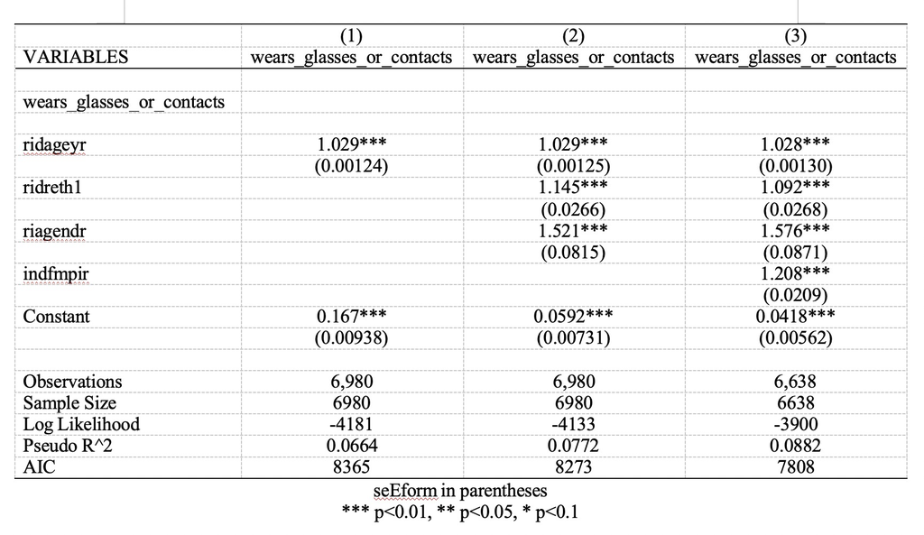

## D. Interpretation

*From the third model, discuss whether the odds of men and women being wears of glasess/contact differs.*

*Test whether the proportion of wearers of glasses/contact differs between men and women.*

```stata
. logit wears_glasses_or_contacts ridageyr ridreth1 riagendr indfmpir

Iteration 0:   log likelihood = -4277.4096
Iteration 1:   log likelihood = -3905.0737
Iteration 2:   log likelihood = -3900.1884
Iteration 3:   log likelihood = -3900.1829
Iteration 4:   log likelihood = -3900.1829

Logistic regression                             Number of obs     =      6,638
                                                LR chi2(4)        =     754.45
                                                Prob > chi2       =     0.0000
Log likelihood = -3900.1829                     Pseudo R2         =     0.0882

-------------------------------------------------------------------------------------------
wears_glasses_or_contacts |      Coef.   Std. Err.      z    P>|z|     [95% Conf. Interval]
--------------------------+----------------------------------------------------------------
                 ridageyr |   .0276009    .001265    21.82   0.000     .0251215    .0300803
                 ridreth1 |   .0880404   .0245416     3.59   0.000     .0399398     .136141
                 riagendr |    .454698   .0552825     8.22   0.000     .3463463    .5630496
                 indfmpir |    .188783   .0173202    10.90   0.000      .154836    .2227299
                    _cons |  -3.174577   .1343728   -23.63   0.000    -3.437943   -2.911211
-------------------------------------------------------------------------------------------


. prtest wears_glasses_or_contacts, by(riagendr)

Two-sample test of proportions                     1: Number of obs =     3383
                                                   2: Number of obs =     3597
------------------------------------------------------------------------------
       Group |       Mean   Std. Err.      z    P>|z|     [95% Conf. Interval]
-------------+----------------------------------------------------------------
           1 |   .3012119   .0078878                      .2857521    .3166718
           2 |   .3783709   .0080864                      .3625218    .3942199
-------------+----------------------------------------------------------------
        diff |  -.0771589   .0112964                     -.0992994   -.0550185
             |  under Ho:   .0113532    -6.80   0.000
------------------------------------------------------------------------------
        diff = prop(1) - prop(2)                                  z =  -6.7962
    Ho: diff = 0

    Ha: diff < 0                 Ha: diff != 0                 Ha: diff > 0
 Pr(Z < z) = 0.0000         Pr(|Z| > |z|) = 0.0000          Pr(Z > z) = 1.0000
```

The coefficient for riagendr is statistically significant at 0.01 level, so there is evidence that the odds of wearing glasses/contact lenses for distance vision differs between men and women.

The coefficient for the riagendr is .454698. The odds ratio is exp(.454698) = 1.5757.

Therefore, as the predictor increases 1, the odds of the outcome occurring increase 57.57%. This means for being a female compared a male, the odds of wearing glasses/contact increase by about 57.57%.

The test shows that the proportion of wearers of glasses/contact for female is .3783709, for male is .3012119. The p-value is below 0.01, so we reject the null hypothesis and conclude that there’s a statistically significant difference in the proportion of glasses/contact lens wearers between male and female.

# Problem 2 - Sakila

## A. Language most common

*Aside from English, what language is most common for films? Answer this with a single SQL query.*

Two “language_id” variables exist in 2 tables. “language_id” is in FILM & LANGUAGE. I do an inner join.

```r
library(DBI)
setwd('C:/Users/hoods/OneDrive/Desktop/Stats 506/Psets/Pset 3')

sakila <- dbConnect(RSQLite::SQLite(), "sakila_master.db")

dbGetQuery(sakila, "SELECT b.language_id
           FROM Film AS b
           INNER JOIN FILM AS p ON b.language_id = p.language_id
LIMIT 5")
```

```
  language_id
1           1
2           1
3           1
4           1
5           1
```

After inspecting the variable, I find that English is the only language used in these films.

## B Most common genre

*What genre of movie is the most common in the data, and how many movies are of this genre?*

```r
film_category <- dbGetQuery(sakila, "SELECT * FROM film_category")

category <- dbGetQuery(sakila, "SELECT * FROM category")

film_counts <- table(film_category$category_id)

# Get the most common genre ID
most_common_genre_id <- as.integer(names(film_counts)[which.max(film_counts)])
most_common_count <- max(film_counts)

# Get the genre name

most_common_genre_name <- subset(category, category_id == most_common_genre_id)$name

print(most_common_genre_name)
```

```
[1] "Sports"
```

The most common genre is sports.

## C. Customers per country

*Identify which country or countries have exactly 9 customers. Answer this with a single SQL query.*

I start by retrieving the tables:

```r
sakila <- dbConnect(RSQLite::SQLite(), "sakila_master.db")

# customer table
customer <- dbGetQuery(sakila, "SELECT * FROM customer")
address <- dbGetQuery(sakila, "SELECT * FROM address")

# city table
city <- dbGetQuery(sakila, "SELECT * FROM city")

# country table
country <- dbGetQuery(sakila, "SELECT * FROM country")
```

In regular R:

```r
# Merge customer with address
customer_address <- merge(customer, address, by="address_id")

# Merge the above result with city
customer_address_city <- merge(customer_address, city, by="city_id")

# Merge the above result with country
merged_data <- merge(customer_address_city, country, by="country_id")
# Count the number of customers per country
country_counts <- table(merged_data$country)

# Filter countries with 9 customers
countries_with_9_customers <- names(country_counts[country_counts == 9])

print(countries_with_9_customers)
```

```
[1] "United Kingdom"
```

The United Kingdom

In SQL

```r
dbGetQuery(sakila, "
SELECT country, COUNT(customer_id) AS customer_count
FROM customer
JOIN address ON customer.address_id = address.address_id
JOIN city ON address.city_id = city.city_id
JOIN country ON city.country_id = country.country_id
GROUP BY country
HAVING customer_count = 9;
")
```

```
         country customer_count
1 United Kingdom              9
```

The country that has customers of 9 is the United Kingdom.

# Problem 3

## A. Domain

*What proportion of email addresses are hosted at a domain with TLD “.net”?*

```r
data <- read.csv('us-500.csv')

length(data$email[grep(".net$", data$email)])
```

```
[1] 70
```

```r
# there are 70 emails ending with ".net".

proportion <- length(data$email[grep(".net$", data$email)]) /
                 length(data$email)

print(proportion)
```

```
[1] 0.14
```

The proportion is 14%.

## B. *alphanumeric*

*What proportion of email addresses have at least one non alphanumeric character in them?*

```r
non_alphaneumeric <- sum(grepl("[^[:alnum:]@.]", data$email))

prop.non_alphaneumeric <- non_alphaneumeric/nrow(data)
print(prop.non_alphaneumeric)
```

```
[1] 0.248
```

The proportion is 24%.

## C. Most common area code

```r
# extract the  numbers
extracted_numbers <- gsub("[^0-9]", "", data$phone1)

# Take the first three digits from each observation
first_three_numbers <- substr(extracted_numbers, 1, 3)

# Count occurrences of each number
number_counts <- table(first_three_numbers)

# Find the most common number
most_common_number <- names(number_counts)[which.max(number_counts)]

cat("Most common number:", most_common_number, "\n")
```

```
Most common number: 973
```

The most common area code is 973

## D. Histogram

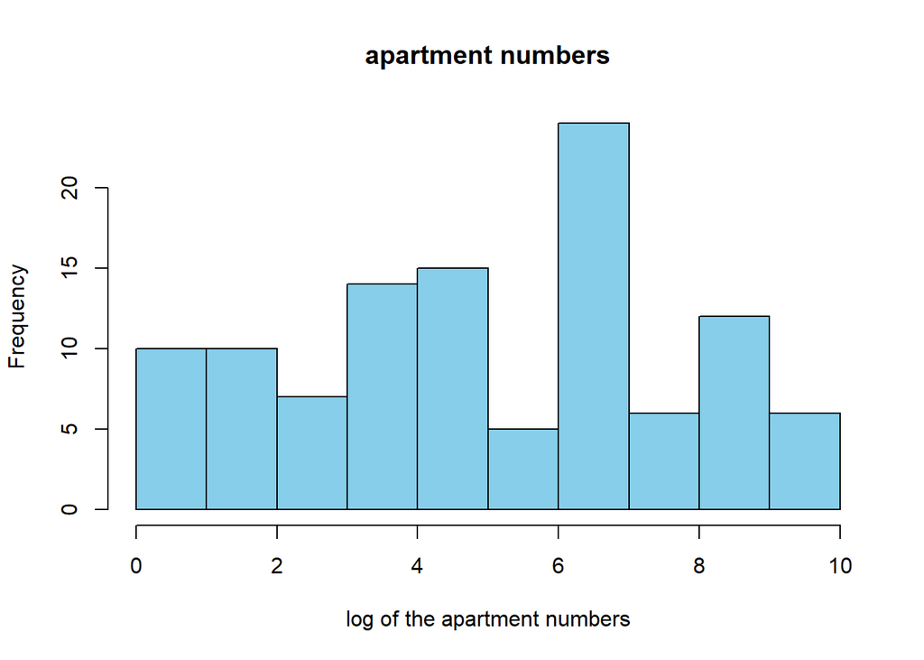

```r
extracted_numbers_address <- gsub(".*#(\\d+)$", "\\1", data$address)
apartment_numbers <- as.numeric(extracted_numbers_address)
cleaned_data <- na.omit(apartment_numbers)

log_cleaned <- log(cleaned_data)

hist(log_cleaned, main="apartment numbers", xlab="log of the apartment numbers", ylab="Frequency", col="skyblue", border="black")
```

## E. Benford’s law

According to Benford’s Law, the distribution of leading digits is expected to be: 1: 30.1% 2: 17.6% 3: 12.5% 4: 9.7% 5: 7.9% 6: 6.7% 7: 5.8% 8: 5.1% 9: 4.6%

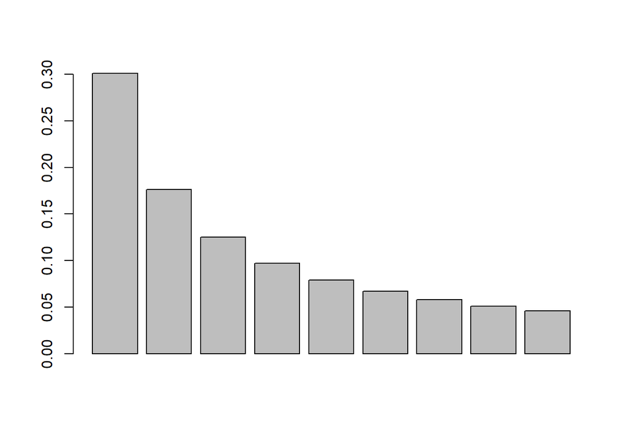

```r
benford_first <- c(0.301, 0.176, 0.125, 0.097, 0.079, 0.067, 0.058, 0.051, 0.046)
benford <- log10(1 + 1 / (1:9))
barplot(benford)
```

```r
leading_digits <- as.integer(substr(apartment_numbers, 1, 1))
# Calculate observed frequencies
observed_first <- table(leading_digits) / length(leading_digits)
head(observed_first)
```

```
leading_digits
    1     2     3     4     5     6
0.022 0.022 0.024 0.022 0.028 0.020
```

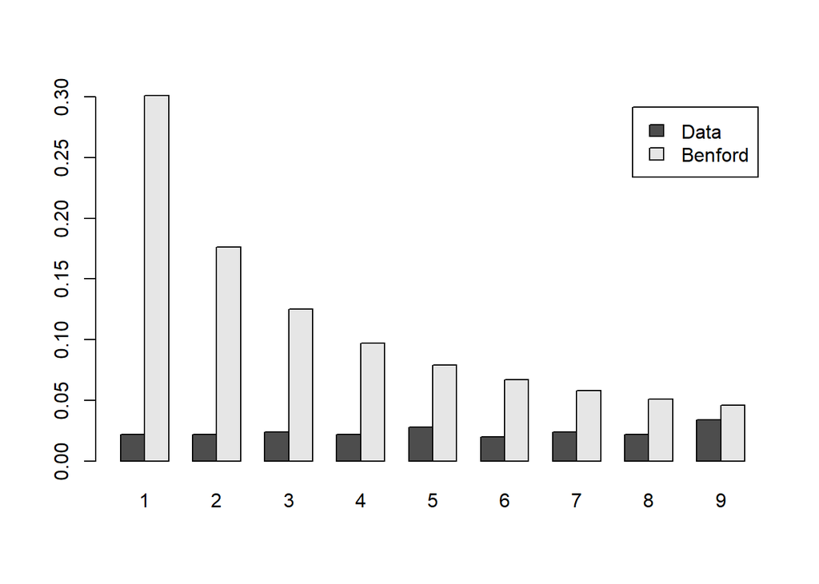

```r
# Compare visually using a barplot
barplot(rbind(observed_first, benford), beside = TRUE, legend.text = c("Data", "Benford"))
```

The apartment numbers do not appear to follow Benford's law.

## F. last digit of the street number

```r
# extracting last digit of the street number
st_number <- sub("^(\\d+).*", "\\1", data$address)
st_number <- as.integer(st_number)
last_digits <- as.integer(substr(st_number, nchar(st_number), nchar(st_number)))

last <- table(last_digits) / length(last_digits)
head(last)
```

```
last_digits
    0     1     2     3     4     5
0.078 0.082 0.108 0.102 0.106 0.104
```

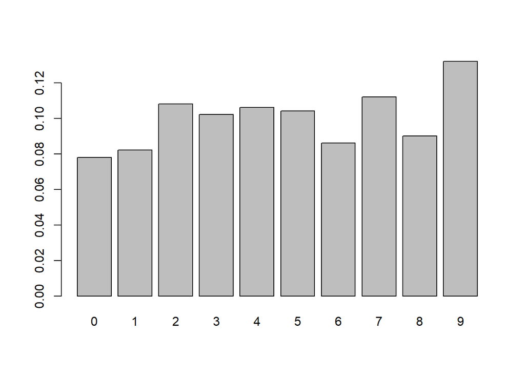

```r
# Comparing
barplot(last)
```